# Prueba de Wilcoxon para una muestra

### Definición:

Prueba utilizada para contrastar la hipótesis sobre la mediana, el centro de la variable cuantitativa. No necesita asumir normalidad de la distribución.

### Hipótesis a contrastar del ejemplo:

$H_0:Mdn_Y=k_0$

$H_1:Mdn_Y\neq{k_0}$

Nuestra constante elegida $k_0=0$.

### Realización:

Para realizar esta prueba, debemos poseer primero una variable sobre la cual contrastar el valor de la mediana, en nuestro caso tiene 50 datos y una distribución aleatoria normal:

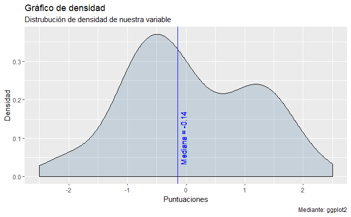

Una vez tenemos la información sobre la cual **vamos a contrastar si** $H_0:Mdn_Y=k_0=0$, debemos obtener **“Di”**, **“S.mas”** y **“R”**.

“Di” es la diferencia entre las observaciones y el valor que hipotetizamos que es el centro de la distribución:

$D_i=X_i-k_0$

```r
#Valor que hipotetizamos que es el centro de nuestra variable
hipotesis <- 0
Di <- datos1 - hipotesis
```

```
Di = -0.8408555 1.384359 -1.255492 0.07014277 1.711441 ...
```

```r
R<-order(abs(Di))
```

```
R = 50 4 43 10 16 ...
```

Obtenemos la siguiente tabla:

|  | V1 | V2 | V3 | V4 | V5 | V6 | V7 | V8 | V9 | V10 | V11 | V12 | V13 | V14 | V15 | V16 | V17 | V18 | V19 | V20 | V21 | V22 | V23 | V24 | V25 | V26 | V27 | V28 | V29 | … |
| --- | --- | --- | --- | --- | --- | --- | --- | --- | --- | --- | --- | --- | --- | --- | --- | --- | --- | --- | --- | --- | --- | --- | --- | --- | --- | --- | --- | --- | --- | --- |
| Xi | -0.8408555 | 1.384359 | -1.255492 | 0.07014277 | 1.711441 | -0.602908 | -0.4721664 | -0.6353713 | -0.2857736 | 0.1381082 | 1.22763 | -0.8017795 | -1.080393 | -0.1575344 | -1.07176 | -0.1389861 | -0.5973131 | -2.183967 | 0.2408173 | -0.2593554 | 0.9005119 | 0.9418694 | 1.467962 | 0.7067611 | 0.8190089 | -0.2934818 | 1.418589 | 1.498774 | -0.6570821 | … |
| Di | -0.8408555 | 1.384359 | -1.255492 | 0.07014277 | 1.711441 | -0.602908 | -0.4721664 | -0.6353713 | -0.2857736 | 0.1381082 | 1.22763 | -0.8017795 | -1.080393 | -0.1575344 | -1.07176 | -0.1389861 | -0.5973131 | -2.183967 | 0.2408173 | -0.2593554 | 0.9005119 | 0.9418694 | 1.467962 | 0.7067611 | 0.8190089 | -0.2934818 | 1.418589 | 1.498774 | -0.6570821 | … |
| \|Di\| | 0.8408555 | 1.384359 | 1.255492 | 0.07014277 | 1.711441 | 0.602908 | 0.4721664 | 0.6353713 | 0.2857736 | 0.1381082 | 1.22763 | 0.8017795 | 1.080393 | 0.1575344 | 1.07176 | 0.1389861 | 0.5973131 | 2.183967 | 0.2408173 | 0.2593554 | 0.9005119 | 0.9418694 | 1.467962 | 0.7067611 | 0.8190089 | 0.2934818 | 1.418589 | 1.498774 | 0.6570821 | … |
| R | 50.0000000 | 4.000000 | 43.000000 | 10.00000000 | 16.000000 | 40.000000 | 14.0000000 | 19.0000000 | 20.0000000 | 9.0000000 | 26.00000 | 31.0000000 | 45.000000 | 48.0000000 | 7.00000 | 46.0000000 | 17.0000000 | 6.000000 | 8.0000000 | 29.0000000 | 24.0000000 | 49.0000000 | 12.000000 | 42.0000000 | 25.0000000 | 1.0000000 | 30.000000 | 47.000000 | 21.0000000 | … |

| *$X_i=D_i$ porque $k_0=0$. |
| --- |
| “S.mas” se calcula a través de la suma de las “R” de los “Di” positivos: |
| $S.mas=S_+=\sum_{i=1}^nR_{i(+)}$ |

En *R*, $S_+$ puede obtenerse de la siguiente forma, considerando que si no hay números positivos, el resultado de $S_+$ es 0:

```r
localiz.positivos<-which(tabla["Di",]>=0)
if(length(localiz.positivos)!=0){
  S.mas<-sum(as.numeric(tabla["R",localiz.positivos]))
}else{
  S.mas<-0
}
cat("S.mas =",S.mas)
```

[output not shown]

### Contraste:

Ahora hay que obtener el punto crítico a través de el estadístico S.mas de Wilcoxon:

- Cuando el tamaño muestral es mayor de 40 puede obtenerse a través de la aproximación a la normal:

$$S_p=\frac{n(n+1)}{4}+Z_p*\sqrt{\frac{n(n+1)(2n+1)}{24}}$$
$$Para\ un\ \alpha=0.05\ el\ valor\ de\ Z_p\ =\ 1.64$$

- Si es menor o igual a 40, se utiliza la distribución de Wilcoxon, que es accesible en R mediante
1. Formula en *R*

```r
alfa <- 0.05
n    <- 50
resultado <- qsignrank(alfa, n , lower.tail=FALSE)
cat("El valor crítico es",resultado)
```

[output not shown]

2. En la imagen de la siguiente tabla:

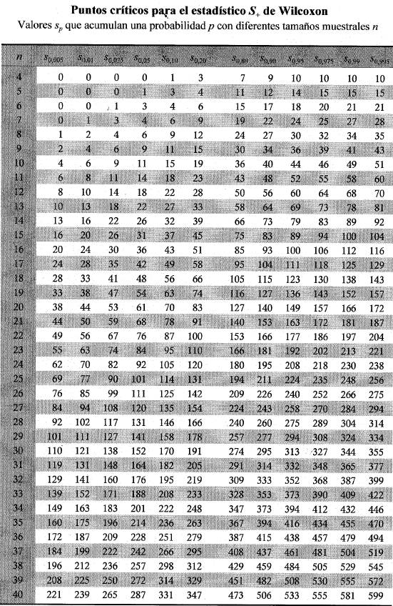

1. En un contraste **unilateral izquierdo**, rechazamos H0 si “S.mas” es menor al punto crítico considerando alfa.
2. En un contraste **unilateral derecho**, rechazamos H0 si “S.mas” es mayor al punto crítico considerando 1 - alfa
3. En un contraste **bilateral**, Rechazamos H0 si “S.mas” es menor que el punto crítico 1 $S_{p1}$, el cual se obtiene considerando $Z_p=\alpha/2$ y mayor al punto crítico 2 $S_{p2}$, el cual se obtiene considerando $Z_p=1-\alpha/2$, como a continuación se muestra:

```r
n    <- 50
alfa <- 0.05
Zp  <- qnorm(alfa / 2)
Sp1 <- n*(n + 1)/4 + Zp*sqrt(n*(n + 1)*(2*n + 1)/24)
Zp  <- qnorm(1 - (alfa / 2))
Sp2 <- n*(n + 1)/4 + Zp*sqrt(n*(n + 1)*(2*n + 1)/24)
cat("Sp1 =", Sp1, "; Sp2=", Sp2, "; S.mas =", S.mas, "\n\n")
```

[output not shown]

En un contraste bilateral, considerando:

1. $S_+=572$
2. $S_{p1}=434.4639072$
3. $S_{p2}=840.5360928$

Como $S_+$ **NO** es menor que $S_{p1}$ **o** mayor que $S_{p2}$

```r
prueba <- S.mas < Sp1 | S.mas > Sp2
cat("El resultado del contraste es:",prueba )
```

[output not shown]